# Unsupervised Learning: Trade&Ahead

## K-means Clustering

```
Number of Clusters: 1 	Average Distortion: 1.0425250298881772
Number of Clusters: 2 	Average Distortion: 0.9249742617202902
Number of Clusters: 3 	Average Distortion: 0.814937727685037
Number of Clusters: 4 	Average Distortion: 0.7421895358080534
Number of Clusters: 5 	Average Distortion: 0.6955872168771203
Number of Clusters: 6 	Average Distortion: 0.6108551254372477
Number of Clusters: 7 	Average Distortion: 0.5521606374687188
Number of Clusters: 8 	Average Distortion: 0.5021107763720115
Number of Clusters: 9 	Average Distortion: 0.4379277300899578
Number of Clusters: 10 	Average Distortion: 0.3903179619638925
Number of Clusters: 11 	Average Distortion: 0.3817889161063022
Number of Clusters: 12 	Average Distortion: 0.37590969652969913
Number of Clusters: 13 	Average Distortion: 0.36921166135438827
Number of Clusters: 14 	Average Distortion: 0.3685901066499892
Number of Clusters: 15 	Average Distortion: 0.35926099311479526
Number of Clusters: 16 	Average Distortion: 0.35314261033371663
Number of Clusters: 17 	Average Distortion: 0.3514644142383354
Number of Clusters: 18 	Average Distortion: 0.34939053719260943
Number of Clusters: 19 	Average Distortion: 0.34595272584834835
Number of Clusters: 20 	Average Distortion: 0.34022343759311235
Number of Clusters: 21 	Average Distortion: 0.3374556919594071
Number of Clusters: 22 	Average Distortion: 0.3338032163785792
Number of Clusters: 23 	Average Distortion: 0.3314640510556362
Number of Clusters: 24 	Average Distortion: 0.3270503651961757
Number of Clusters: 25 	Average Distortion: 0.32406871441767343
Number of Clusters: 26 	Average Distortion: 0.32087712284566816
Number of Clusters: 27 	Average Distortion: 0.3204078807058601
Number of Clusters: 28 	Average Distortion: 0.31619941503547383
Number of Clusters: 29 	Average Distortion: 0.3134020295567996
```

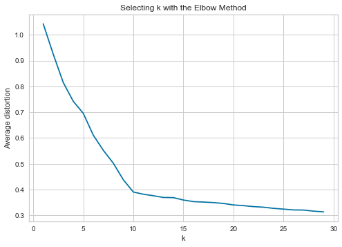

```python
clusters = range(1, 30)
meanDistortions = []

for k in clusters:
    model = KMeans(n_clusters=k)
    model.fit(stock_data)
    prediction = model.predict(stock_data)
    distortion = (
        sum(
            np.min(cdist(stock_data, model.cluster_centers_, "euclidean"), axis=1)
        )
        / stock_data.shape[0]
    )

    meanDistortions.append(distortion)

    print("Number of Clusters:", k, "\tAverage Distortion:", distortion)

plt.plot(clusters, meanDistortions, "bx-")
plt.xlabel("k")
plt.ylabel("Average distortion")
plt.title("Selecting k with the Elbow Method")
plt.show()
```

```
For n_clusters = 2, the silhouette score is 0.1751309022731382)
For n_clusters = 3, the silhouette score is 0.2632260803941414)
For n_clusters = 4, the silhouette score is 0.306791464961593)
For n_clusters = 5, the silhouette score is 0.38230648243857723)
For n_clusters = 6, the silhouette score is 0.438642614536334)
For n_clusters = 7, the silhouette score is 0.5013483973263738)
For n_clusters = 8, the silhouette score is 0.556983594569254)
For n_clusters = 9, the silhouette score is 0.5921350327217103)
For n_clusters = 10, the silhouette score is 0.6270559939228986)
For n_clusters = 11, the silhouette score is 0.5804332597472147)
For n_clusters = 12, the silhouette score is 0.587820129119612)
For n_clusters = 13, the silhouette score is 0.5069528079297232)
For n_clusters = 14, the silhouette score is 0.49679252701680926)
For n_clusters = 15, the silhouette score is 0.48973699208859356)
For n_clusters = 16, the silhouette score is 0.4698201791186369)
For n_clusters = 17, the silhouette score is 0.46744626032694864)
For n_clusters = 18, the silhouette score is 0.41123938609749516)
For n_clusters = 19, the silhouette score is 0.3030763330548677)
For n_clusters = 20, the silhouette score is 0.43920580297078726)
For n_clusters = 21, the silhouette score is 0.31133875461941907)
For n_clusters = 22, the silhouette score is 0.36568833187316485)
For n_clusters = 23, the silhouette score is 0.2733921365918715)
For n_clusters = 24, the silhouette score is 0.26873681794719756)
For n_clusters = 25, the silhouette score is 0.26486444102933465)
For n_clusters = 26, the silhouette score is 0.2726267547048546)
For n_clusters = 27, the silhouette score is 0.18207151382479464)
For n_clusters = 28, the silhouette score is 0.25131768798848414)
For n_clusters = 29, the silhouette score is 0.22261446176568894)
```

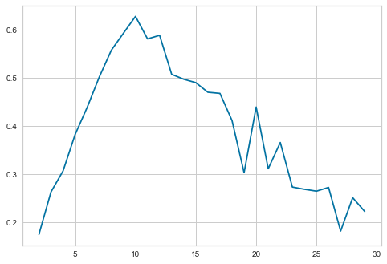

```python
sil_score = []
cluster_list = list(range(2, 30))
for n_clusters in cluster_list:
    clusterer = KMeans(n_clusters=n_clusters)
    preds = clusterer.fit_predict((stock_data))
    # centers = clusterer.cluster_centers_
    score = silhouette_score(stock_data, preds)
    sil_score.append(score)
    print("For n_clusters = {}, the silhouette score is {})".format(n_clusters, score))

plt.plot(cluster_list, sil_score)
plt.show()
```

## Observations:

- It appears that the optimal number of clusters is 10.
- This is based on the silhouette scores and the elbow plot.

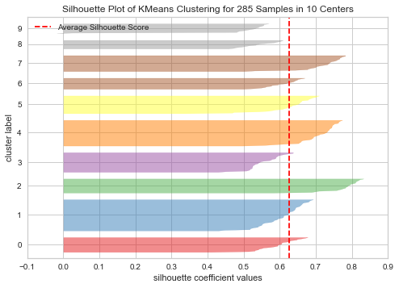

```python
visualizer = SilhouetteVisualizer(KMeans(10, random_state=1))
visualizer.fit(stock_data)
visualizer.show()
```

```python
kmeans = KMeans(n_clusters=10, random_state=0)
kmeans.fit(stock_data)
```

```
KMeans(n_clusters=10, random_state=0)
```

```python
stock_data['K_means_segments'] = kmeans.labels_
```

## Cluster Profiling

```python
cluster_profile = stock_data.groupby('K_means_segments').mean()
```

```python
cluster_profile['count_in_each_segments'] = (
    stock_data.groupby('K_means_segments')['Current Price'].count().values
)
```

```python
cluster_profile.style.highlight_max(color="lightgreen", axis=0)
```

| K_means_segments | Current Price | Price Change | Volatility | ROE | Cash Ratio | Net Cash Flow | Net Income | Earnings Per Share | Estimated Shares Outstanding | P/E Ratio | P/B Ratio | Sector_Consumer Discretionary | Sector_Consumer Staples | Sector_Energy | Sector_Financials | Sector_Health Care | Sector_Industrials | Sector_Information Technology | Sector_Materials | Sector_Real Estate | Sector_Telecommunications Services | Sector_Utilities | count_in_each_segments |
| --- | --- | --- | --- | --- | --- | --- | --- | --- | --- | --- | --- | --- | --- | --- | --- | --- | --- | --- | --- | --- | --- | --- | --- |
| 0 | 0.556087 | 0.431034 | 0.519876 | 0.556790 | 0.440616 | 0.429012 | 0.455851 | 0.538916 | 0.451135 | 0.469813 | 0.547348 | 0.000000 | 0.000000 | 0.000000 | 0.000000 | 0.000000 | 1.000000 | 0.000000 | 0.000000 | 0.000000 | 0.000000 | 0.000000 | 52 |
| 1 | 0.643080 | 0.530867 | 0.578495 | 0.499013 | 0.553314 | 0.464684 | 0.440082 | 0.521873 | 0.491050 | 0.599357 | 0.510781 | 0.000000 | 0.000000 | 0.000000 | 0.000000 | 1.000000 | 0.000000 | 0.000000 | 0.000000 | 0.000000 | 0.000000 | 0.000000 | 33 |
| 2 | 0.507773 | 0.445549 | 0.468832 | 0.441542 | 0.666808 | 0.471225 | 0.454416 | 0.528203 | 0.502072 | 0.452580 | 0.505262 | 0.000000 | 0.000000 | 0.000000 | 1.000000 | 0.000000 | 0.000000 | 0.000000 | 0.000000 | 0.000000 | 0.000000 | 0.000000 | 43 |
| 3 | 0.543874 | 0.489272 | 0.551641 | 0.542141 | 0.418559 | 0.446302 | 0.436545 | 0.504803 | 0.450415 | 0.514954 | 0.534582 | 1.000000 | 0.000000 | 0.000000 | 0.000000 | 0.000000 | 0.000000 | 0.000000 | 0.000000 | 0.000000 | 0.000000 | 0.000000 | 30 |
| 4 | 0.587329 | 0.489494 | 0.446595 | 0.437370 | 0.519114 | 0.445341 | 0.399485 | 0.472197 | 0.436640 | 0.657519 | 0.510497 | 0.000000 | 0.000000 | 0.000000 | 0.000000 | 0.000000 | 0.000000 | 0.000000 | 0.000000 | 1.000000 | 0.000000 | 0.000000 | 27 |
| 5 | 0.488819 | 0.479813 | 0.583291 | 0.518174 | 0.649288 | 0.426644 | 0.450495 | 0.472774 | 0.555639 | 0.554358 | 0.596868 | 0.000000 | 0.000000 | 0.000000 | 0.000000 | 0.000000 | 0.000000 | 1.000000 | 0.000000 | 0.000000 | 0.000000 | 0.000000 | 25 |
| 6 | 0.560130 | 0.519046 | 0.624243 | 0.510062 | 0.443458 | 0.419951 | 0.422399 | 0.524921 | 0.424010 | 0.517311 | 0.561670 | 0.000000 | 0.000000 | 0.000000 | 0.000000 | 0.000000 | 0.000000 | 0.000000 | 0.904762 | 0.000000 | 0.095238 | 0.000000 | 21 |
| 7 | 0.504434 | 0.401343 | 0.401336 | 0.420395 | 0.296147 | 0.462455 | 0.425146 | 0.484889 | 0.484006 | 0.491542 | 0.508966 | 0.000000 | 0.000000 | 0.000000 | 0.000000 | 0.000000 | 0.000000 | 0.000000 | 0.000000 | 0.000000 | 0.000000 | 1.000000 | 24 |
| 8 | 0.501666 | 0.356067 | 0.762750 | 0.466271 | 0.494101 | 0.398693 | 0.355047 | 0.362867 | 0.530464 | 0.689974 | 0.660220 | 0.000000 | 0.000000 | 1.000000 | 0.000000 | 0.000000 | 0.000000 | 0.000000 | 0.000000 | 0.000000 | 0.000000 | 0.000000 | 15 |
| 9 | 0.570664 | 0.524329 | 0.411335 | 0.573133 | 0.476925 | 0.478290 | 0.491613 | 0.505888 | 0.548909 | 0.528071 | 0.471937 | 0.000000 | 1.000000 | 0.000000 | 0.000000 | 0.000000 | 0.000000 | 0.000000 | 0.000000 | 0.000000 | 0.000000 | 0.000000 | 15 |

```python
cluster_profile.reset_index(drop = False, inplace = True)
```

```python
num_cols = list(stock_data.columns)
```

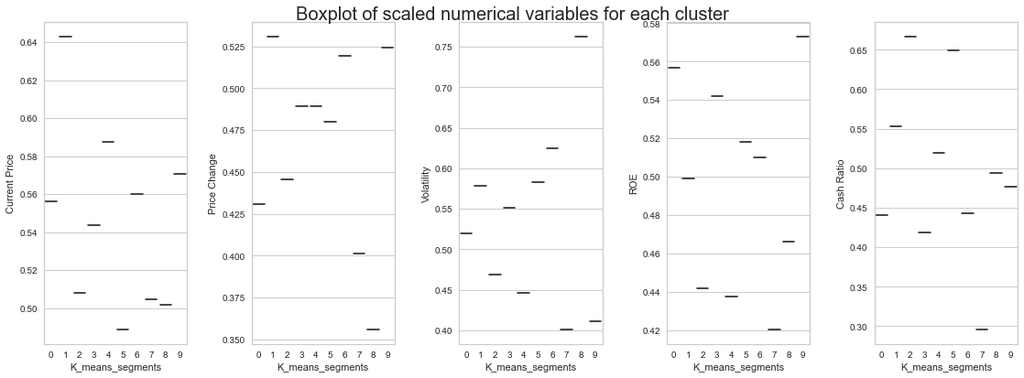

```python
fig, axes = plt.subplots(1, 5, figsize=(16, 6))
fig.suptitle("Boxplot of scaled numerical variables for each cluster", fontsize=20)
counter = 0
for ii in range(5):
    sns.boxplot(
        ax=axes[ii],
        y=cluster_profile[num_col[counter]],
        x=cluster_profile['K_means_segments'],
    )
    counter = counter + 1

fig.tight_layout(pad=2.0)
```

### Observations:

- The clusters appear distinctive across the main numerical columns.
- 10 clusters is the optimal number of clusters.

## Hierarchical Clustering

```python
# list of distance metrics
distance_metrics = ["euclidean", "chebyshev", "cityblock"]
# distance_metrics = ["euclidean", "chebyshev", "mahalanobis", "cityblock"]

# list of linkage methods
linkage_methods = ["single", "complete", "average", "weighted"]

high_cophenet_corr = 0
high_dm_lm = [0, 0]

for dm in distance_metrics:
    for lm in linkage_methods:
        Z = linkage(cluster_profile, metric=dm, method=lm)
        c, coph_dists = cophenet(Z, pdist(cluster_profile))
        print(
            "Cophenetic correlation for {} distance and {} linkage is {}.".format(
                dm.capitalize(), lm, c
            )
        )
        if high_cophenet_corr < c:
            high_cophenet_corr = c
            high_dm_lm[0] = dm
            high_dm_lm[1] = lm
```

```
Cophenetic correlation for Euclidean distance and single linkage is 0.8011232761564357.
Cophenetic correlation for Euclidean distance and complete linkage is 0.828774582172435.
Cophenetic correlation for Euclidean distance and average linkage is 0.8306758613270334.
Cophenetic correlation for Euclidean distance and weighted linkage is 0.8302667658786026.
Cophenetic correlation for Chebyshev distance and single linkage is 0.8001720756926531.
Cophenetic correlation for Chebyshev distance and complete linkage is 0.8294486297840109.
Cophenetic correlation for Chebyshev distance and average linkage is 0.8305976547245466.
Cophenetic correlation for Chebyshev distance and weighted linkage is 0.8096452341687024.
Cophenetic correlation for Cityblock distance and single linkage is 0.7719503162021868.
Cophenetic correlation for Cityblock distance and complete linkage is 0.8255708917365071.
Cophenetic correlation for Cityblock distance and average linkage is 0.8289741328324288.
Cophenetic correlation for Cityblock distance and weighted linkage is 0.828247505096875.
```

```python
# printing the combination of distance metric and linkage method with the highest cophenetic correlation
print(
    "Highest cophenetic correlation is {}, which is obtained with {} distance and {} linkage.".format(
        high_cophenet_corr, high_dm_lm[0].capitalize(), high_dm_lm[1]
    )
)
```

```
Highest cophenetic correlation is 0.8306758613270334, which is obtained with Euclidean distance and average linkage.
```

```python
# list of linkage methods
linkage_methods = ["single", "complete", "average", "centroid", "ward", "weighted"]

high_cophenet_corr = 0
high_dm_lm = [0, 0]

for lm in linkage_methods:
    Z = linkage(cluster_profile, metric="euclidean", method=lm)
    c, coph_dists = cophenet(Z, pdist(cluster_profile))
    print("Cophenetic correlation for {} linkage is {}.".format(lm, c))
    if high_cophenet_corr < c:
        high_cophenet_corr = c
        high_dm_lm[0] = "euclidean"
        high_dm_lm[1] = lm
```

```
Cophenetic correlation for single linkage is 0.8011232761564357.
Cophenetic correlation for complete linkage is 0.828774582172435.
Cophenetic correlation for average linkage is 0.8306758613270334.
Cophenetic correlation for centroid linkage is 0.8307760066069917.
Cophenetic correlation for ward linkage is 0.8291564820910827.
Cophenetic correlation for weighted linkage is 0.8302667658786026.
```

```python
# printing the combination of distance metric and linkage method with the highest cophenetic correlation
print(
    "Highest cophenetic correlation is {}, which is obtained with {} linkage.".format(
        high_cophenet_corr, high_dm_lm[1]
    )
)
```

```
Highest cophenetic correlation is 0.8307760066069917, which is obtained with centroid linkage.
```

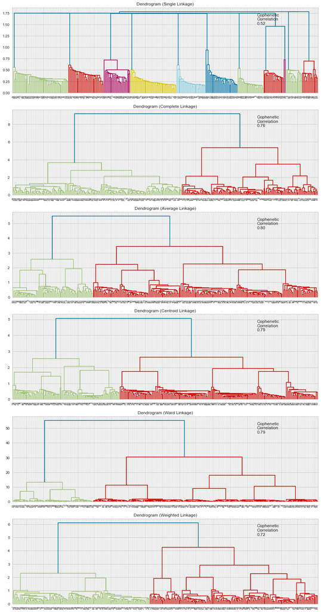

```python
# list of linkage methods
linkage_methods = ["single", "complete", "average", "centroid", "ward", "weighted"]

# lists to save results of cophenetic correlation calculation
compare_cols = ["Linkage", "Cophenetic Coefficient"]

# to create a subplot image
fig, axs = plt.subplots(len(linkage_methods), 1, figsize=(15, 30))

# We will enumerate through the list of linkage methods above
# For each linkage method, we will plot the dendrogram and calculate the cophenetic correlation
for i, method in enumerate(linkage_methods):
    Z = linkage(stock_data, metric="euclidean", method=method)

    dendrogram(Z, ax=axs[i])
    axs[i].set_title(f"Dendrogram ({method.capitalize()} Linkage)")

    coph_corr, coph_dist = cophenet(Z, pdist(stock_data))
    axs[i].annotate(
        f"Cophenetic\nCorrelation\n{coph_corr:0.2f}",
        (0.80, 0.80),
        xycoords="axes fraction",
    )
```

```python
HCmodel = AgglomerativeClustering(n_clusters=6, affinity="euclidean", linkage="average")
HCmodel.fit(stock_data)
```

```
AgglomerativeClustering(linkage='average', n_clusters=6)
```

```python
stock_data["HC_Clusters"] = HCmodel.labels_
```

## Cluster Profiling

```python
cluster_profile_2 = stock_data.groupby("HC_Clusters").mean()
```

```python
cluster_profile_2["count_in_each_segments"] = (
    stock_data.groupby("HC_Clusters")['Current Price'].count().values
)
```

```python
cluster_profile_2.style.highlight_max(color="lightgreen", axis=0)
```

| HC_Clusters | Current Price | Price Change | Volatility | ROE | Cash Ratio | Net Cash Flow | Net Income | Earnings Per Share | Estimated Shares Outstanding | P/E Ratio | P/B Ratio | Sector_Consumer Discretionary | Sector_Consumer Staples | Sector_Energy | Sector_Financials | Sector_Health Care | Sector_Industrials | Sector_Information Technology | Sector_Materials | Sector_Real Estate | Sector_Telecommunications Services | Sector_Utilities | K_means_segments | count_in_each_segments |
| --- | --- | --- | --- | --- | --- | --- | --- | --- | --- | --- | --- | --- | --- | --- | --- | --- | --- | --- | --- | --- | --- | --- | --- | --- |
| 0 | 0.536165 | 0.440198 | 0.587042 | 0.519702 | 0.485513 | 0.438492 | 0.423330 | 0.434378 | 0.539686 | 0.609022 | 0.566079 | 0.000000 | 0.500000 | 0.500000 | 0.000000 | 0.000000 | 0.000000 | 0.000000 | 0.000000 | 0.000000 | 0.000000 | 0.000000 | 8.500000 | 30 |
| 1 | 0.530425 | 0.456271 | 0.505360 | 0.462240 | 0.364892 | 0.442620 | 0.423864 | 0.503571 | 0.456008 | 0.503568 | 0.533561 | 0.000000 | 0.000000 | 0.000000 | 0.000000 | 0.000000 | 0.000000 | 0.000000 | 0.422222 | 0.000000 | 0.044444 | 0.533333 | 6.533333 | 45 |
| 2 | 0.566524 | 0.482595 | 0.516449 | 0.466497 | 0.617527 | 0.468385 | 0.448192 | 0.525455 | 0.497286 | 0.516312 | 0.507658 | 0.000000 | 0.000000 | 0.000000 | 0.565789 | 0.434211 | 0.000000 | 0.000000 | 0.000000 | 0.000000 | 0.000000 | 0.000000 | 1.565789 | 76 |
| 3 | 0.564458 | 0.489377 | 0.501882 | 0.492513 | 0.466190 | 0.445847 | 0.418990 | 0.489358 | 0.443890 | 0.582485 | 0.523173 | 0.526316 | 0.000000 | 0.000000 | 0.000000 | 0.000000 | 0.000000 | 0.000000 | 0.000000 | 0.473684 | 0.000000 | 0.000000 | 3.473684 | 57 |
| 4 | 0.556087 | 0.431034 | 0.519876 | 0.556790 | 0.440616 | 0.429012 | 0.455851 | 0.538916 | 0.451135 | 0.469813 | 0.547348 | 0.000000 | 0.000000 | 0.000000 | 0.000000 | 0.000000 | 1.000000 | 0.000000 | 0.000000 | 0.000000 | 0.000000 | 0.000000 | 0.000000 | 52 |
| 5 | 0.488819 | 0.479813 | 0.583291 | 0.518174 | 0.649288 | 0.426644 | 0.450495 | 0.472774 | 0.555639 | 0.554358 | 0.596868 | 0.000000 | 0.000000 | 0.000000 | 0.000000 | 0.000000 | 0.000000 | 1.000000 | 0.000000 | 0.000000 | 0.000000 | 0.000000 | 5.000000 | 25 |

```python
num_cols = list(stock_data.columns)
```

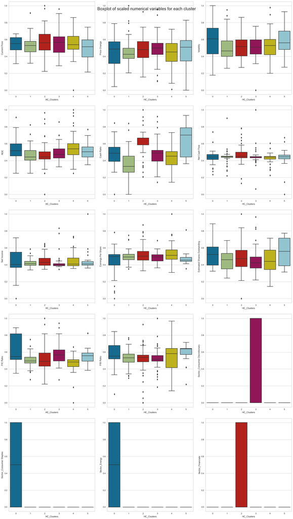

```python
fig, axes = plt.subplots(5, 3, figsize=(20, 35))
fig.suptitle("Boxplot of scaled numerical variables for each cluster", fontsize=20)
counter = 0
for ii in range(5):
    sns.boxplot(
        ax=axes[ii][0],
        y=stock_data[num_cols[counter]],
        x=stock_data["HC_Clusters"],
    )
    counter = counter + 1
    sns.boxplot(
        ax=axes[ii][1],
        y=stock_data[num_cols[counter]],
        x=stock_data["HC_Clusters"],
    )
    counter = counter + 1
    sns.boxplot(
        ax=axes[ii][2],
        y=stock_data[num_cols[counter]],
        x=stock_data["HC_Clusters"],
    )
    counter = counter + 1


fig.tight_layout(pad=2.0)
```

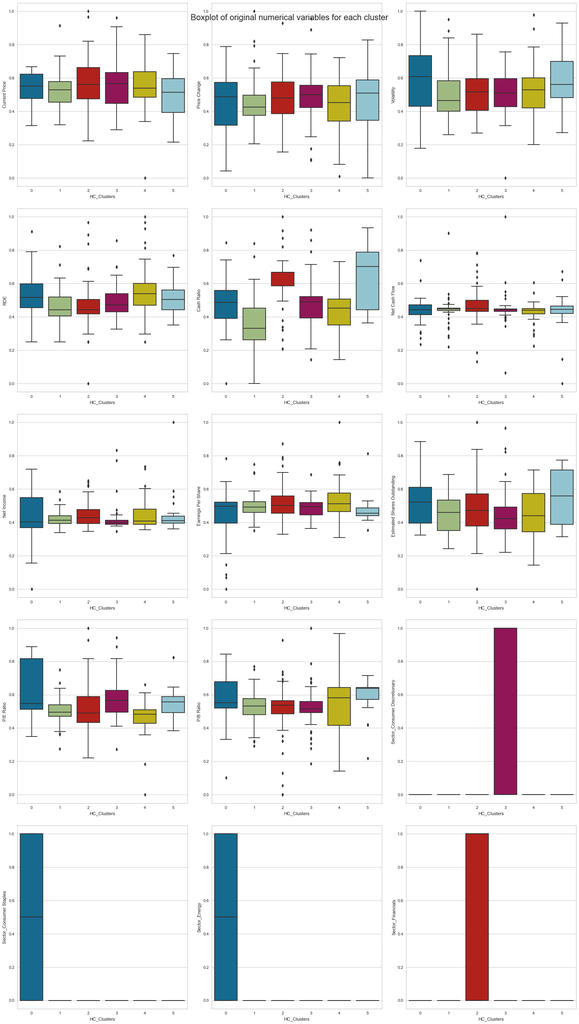

```python
fig, axes = plt.subplots(5, 3, figsize=(20, 35))
fig.suptitle("Boxplot of original numerical variables for each cluster", fontsize=20)
counter = 0
for ii in range(5):
    sns.boxplot(ax=axes[ii][0], y=stock_data[num_cols[counter]], x=stock_data["HC_Clusters"])
    counter = counter + 1
    sns.boxplot(ax=axes[ii][1], y=stock_data[num_cols[counter]], x=stock_data["HC_Clusters"])
    counter = counter + 1
    sns.boxplot(ax=axes[ii][2], y=stock_data[num_cols[counter]], x=stock_data["HC_Clusters"])
    counter = counter + 1

fig.tight_layout(pad=2.0)
```

### Observations:

1. There hierarchal clustering tends to form clusters based on the indicator fields.
2. Otherwise, the clusters are fairly close together. This may be an issue with the data pre-processing performed on the one-hot encoded features.
3. One-hot encoded features should be scaled such that their distance is equivalent to a standard deviation in the other fields.

```python
from sklearn.decomposition import PCA

# setting the number of components to 2
pca = PCA(n_components=2)

# transforming data and storing results in a dataframe
X_reduced_pca = pca.fit_transform(stock_data)
reduced_df_pca = pd.DataFrame(
    data=X_reduced_pca, columns=["Component 1", "Component 2"]
)
```

```python
pca.explained_variance_ratio_.sum()
```

```
0.9185264906607346
```

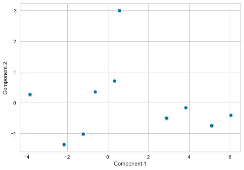

```python
sns.scatterplot(data=reduced_df_pca, x="Component 1", y="Component 2")
```

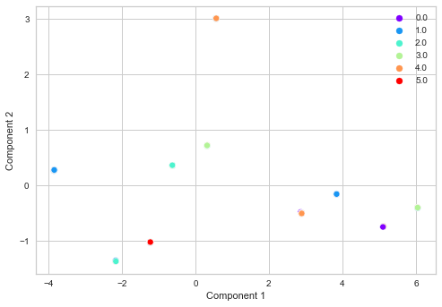

```python
sns.scatterplot(
    data=reduced_df_pca,
    x="Component 1",
    y="Component 2",
    hue=stock_data["HC_Clusters"],
    palette="rainbow",
)
plt.legend(bbox_to_anchor=(1, 1))
```

## K-means vs Hierarchical Clustering

You compare several things, like:

- Which clustering technique took less time for execution?
- Which clustering technique gave you more distinct clusters, or are they the same?
- How many observations are there in the similar clusters of both algorithms?
- How many clusters are obtained as the appropriate number of clusters from both algorithms?

You can also mention any differences or similarities you obtained in the cluster profiles from both the clustering techniques.

### Which clustering technique took less time for execution?

K-means performs quicker than hierarchal clustering.

### Which clustering technique gave you more distinct clusters, or are they the same?

K-means clustering provided more distinct clusterings. K-means provided 10 clusterings while hierarchal provided 6 clusterings.

### How many observations are there in the similar clusters of both algorithms?

```python
cluster_profile.style.highlight_max(color="lightgreen", axis=0)
```

|  | K_means_segments | Current Price | Price Change | Volatility | ROE | Cash Ratio | Net Cash Flow | Net Income | Earnings Per Share | Estimated Shares Outstanding | P/E Ratio | P/B Ratio | Sector_Consumer Discretionary | Sector_Consumer Staples | Sector_Energy | Sector_Financials | Sector_Health Care | Sector_Industrials | Sector_Information Technology | Sector_Materials | Sector_Real Estate | Sector_Telecommunications Services | Sector_Utilities | count_in_each_segments |
| --- | --- | --- | --- | --- | --- | --- | --- | --- | --- | --- | --- | --- | --- | --- | --- | --- | --- | --- | --- | --- | --- | --- | --- | --- |
| 0 | 0 | 0.556087 | 0.431034 | 0.519876 | 0.556790 | 0.440616 | 0.429012 | 0.455851 | 0.538916 | 0.451135 | 0.469813 | 0.547348 | 0.000000 | 0.000000 | 0.000000 | 0.000000 | 0.000000 | 1.000000 | 0.000000 | 0.000000 | 0.000000 | 0.000000 | 0.000000 | 52 |
| 1 | 1 | 0.643080 | 0.530867 | 0.578495 | 0.499013 | 0.553314 | 0.464684 | 0.440082 | 0.521873 | 0.491050 | 0.599357 | 0.510781 | 0.000000 | 0.000000 | 0.000000 | 0.000000 | 1.000000 | 0.000000 | 0.000000 | 0.000000 | 0.000000 | 0.000000 | 0.000000 | 33 |
| 2 | 2 | 0.507773 | 0.445549 | 0.468832 | 0.441542 | 0.666808 | 0.471225 | 0.454416 | 0.528203 | 0.502072 | 0.452580 | 0.505262 | 0.000000 | 0.000000 | 0.000000 | 1.000000 | 0.000000 | 0.000000 | 0.000000 | 0.000000 | 0.000000 | 0.000000 | 0.000000 | 43 |
| 3 | 3 | 0.543874 | 0.489272 | 0.551641 | 0.542141 | 0.418559 | 0.446302 | 0.436545 | 0.504803 | 0.450415 | 0.514954 | 0.534582 | 1.000000 | 0.000000 | 0.000000 | 0.000000 | 0.000000 | 0.000000 | 0.000000 | 0.000000 | 0.000000 | 0.000000 | 0.000000 | 30 |
| 4 | 4 | 0.587329 | 0.489494 | 0.446595 | 0.437370 | 0.519114 | 0.445341 | 0.399485 | 0.472197 | 0.436640 | 0.657519 | 0.510497 | 0.000000 | 0.000000 | 0.000000 | 0.000000 | 0.000000 | 0.000000 | 0.000000 | 0.000000 | 1.000000 | 0.000000 | 0.000000 | 27 |
| 5 | 5 | 0.488819 | 0.479813 | 0.583291 | 0.518174 | 0.649288 | 0.426644 | 0.450495 | 0.472774 | 0.555639 | 0.554358 | 0.596868 | 0.000000 | 0.000000 | 0.000000 | 0.000000 | 0.000000 | 0.000000 | 1.000000 | 0.000000 | 0.000000 | 0.000000 | 0.000000 | 25 |
| 6 | 6 | 0.560130 | 0.519046 | 0.624243 | 0.510062 | 0.443458 | 0.419951 | 0.422399 | 0.524921 | 0.424010 | 0.517311 | 0.561670 | 0.000000 | 0.000000 | 0.000000 | 0.000000 | 0.000000 | 0.000000 | 0.000000 | 0.904762 | 0.000000 | 0.095238 | 0.000000 | 21 |
| 7 | 7 | 0.504434 | 0.401343 | 0.401336 | 0.420395 | 0.296147 | 0.462455 | 0.425146 | 0.484889 | 0.484006 | 0.491542 | 0.508966 | 0.000000 | 0.000000 | 0.000000 | 0.000000 | 0.000000 | 0.000000 | 0.000000 | 0.000000 | 0.000000 | 0.000000 | 1.000000 | 24 |
| 8 | 8 | 0.501666 | 0.356067 | 0.762750 | 0.466271 | 0.494101 | 0.398693 | 0.355047 | 0.362867 | 0.530464 | 0.689974 | 0.660220 | 0.000000 | 0.000000 | 1.000000 | 0.000000 | 0.000000 | 0.000000 | 0.000000 | 0.000000 | 0.000000 | 0.000000 | 0.000000 | 15 |
| 9 | 9 | 0.570664 | 0.524329 | 0.411335 | 0.573133 | 0.476925 | 0.478290 | 0.491613 | 0.505888 | 0.548909 | 0.528071 | 0.471937 | 0.000000 | 1.000000 | 0.000000 | 0.000000 | 0.000000 | 0.000000 | 0.000000 | 0.000000 | 0.000000 | 0.000000 | 0.000000 | 15 |

```python
cluster_profile_2.style.highlight_max(color="lightgreen", axis=0)
```

| HC_Clusters | Current Price | Price Change | Volatility | ROE | Cash Ratio | Net Cash Flow | Net Income | Earnings Per Share | Estimated Shares Outstanding | P/E Ratio | P/B Ratio | Sector_Consumer Discretionary | Sector_Consumer Staples | Sector_Energy | Sector_Financials | Sector_Health Care | Sector_Industrials | Sector_Information Technology | Sector_Materials | Sector_Real Estate | Sector_Telecommunications Services | Sector_Utilities | K_means_segments | count_in_each_segments |
| --- | --- | --- | --- | --- | --- | --- | --- | --- | --- | --- | --- | --- | --- | --- | --- | --- | --- | --- | --- | --- | --- | --- | --- | --- |
| 0 | 0.536165 | 0.440198 | 0.587042 | 0.519702 | 0.485513 | 0.438492 | 0.423330 | 0.434378 | 0.539686 | 0.609022 | 0.566079 | 0.000000 | 0.500000 | 0.500000 | 0.000000 | 0.000000 | 0.000000 | 0.000000 | 0.000000 | 0.000000 | 0.000000 | 0.000000 | 8.500000 | 30 |
| 1 | 0.530425 | 0.456271 | 0.505360 | 0.462240 | 0.364892 | 0.442620 | 0.423864 | 0.503571 | 0.456008 | 0.503568 | 0.533561 | 0.000000 | 0.000000 | 0.000000 | 0.000000 | 0.000000 | 0.000000 | 0.000000 | 0.422222 | 0.000000 | 0.044444 | 0.533333 | 6.533333 | 45 |
| 2 | 0.566524 | 0.482595 | 0.516449 | 0.466497 | 0.617527 | 0.468385 | 0.448192 | 0.525455 | 0.497286 | 0.516312 | 0.507658 | 0.000000 | 0.000000 | 0.000000 | 0.565789 | 0.434211 | 0.000000 | 0.000000 | 0.000000 | 0.000000 | 0.000000 | 0.000000 | 1.565789 | 76 |
| 3 | 0.564458 | 0.489377 | 0.501882 | 0.492513 | 0.466190 | 0.445847 | 0.418990 | 0.489358 | 0.443890 | 0.582485 | 0.523173 | 0.526316 | 0.000000 | 0.000000 | 0.000000 | 0.000000 | 0.000000 | 0.000000 | 0.000000 | 0.473684 | 0.000000 | 0.000000 | 3.473684 | 57 |
| 4 | 0.556087 | 0.431034 | 0.519876 | 0.556790 | 0.440616 | 0.429012 | 0.455851 | 0.538916 | 0.451135 | 0.469813 | 0.547348 | 0.000000 | 0.000000 | 0.000000 | 0.000000 | 0.000000 | 1.000000 | 0.000000 | 0.000000 | 0.000000 | 0.000000 | 0.000000 | 0.000000 | 52 |
| 5 | 0.488819 | 0.479813 | 0.583291 | 0.518174 | 0.649288 | 0.426644 | 0.450495 | 0.472774 | 0.555639 | 0.554358 | 0.596868 | 0.000000 | 0.000000 | 0.000000 | 0.000000 | 0.000000 | 0.000000 | 1.000000 | 0.000000 | 0.000000 | 0.000000 | 0.000000 | 5.000000 | 25 |

## Actionable Insights and Recommendations